# Self-Driving Car Engineer Nanodegree

## Project: Build a Traffic Sign Recognition Classifier

In this notebook, a template is provided for you to implement your functionality in stages, which is required to successfully complete this project. If additional code is required that cannot be included in the notebook, be sure that the Python code is successfully imported and included in your submission if necessary.

In addition to implementing code, there is a writeup to complete. The writeup should be completed in a separate file, which can be either a markdown file or a pdf document. There is a [write up template](https://github.com/udacity/CarND-Traffic-Sign-Classifier-Project/blob/master/writeup_template.md) that can be used to guide the writing process. Completing the code template and writeup template will cover all of the [rubric points](https://review.udacity.com/#!/rubrics/481/view) for this project.

The [rubric](https://review.udacity.com/#!/rubrics/481/view) contains "Stand Out Suggestions" for enhancing the project beyond the minimum requirements. The stand out suggestions are optional. If you decide to pursue the "stand out suggestions", you can include the code in this Ipython notebook and also discuss the results in the writeup file.

> **Note:** Code and Markdown cells can be executed using the **Shift + Enter** keyboard shortcut. In addition, Markdown cells can be edited by typically double-clicking the cell to enter edit mode.

## Step 0: Load The Data

```python
# Load pickled data
import pickle

# TODO: Fill this in based on where you saved the training and testing data

training_file = './data/train.p'
validation_file= './data/valid.p'
testing_file = './data/test.p'
```

```python
def load_data(file):
    """
    Loads the dataset from a pickle file and returns a dataset
    """

    with open(file, mode='rb') as f:
        data = None
        data = pickle.load(f)
    return data['features'], data['labels']
```

```python
def save_data(file, features, labels):
    """
    Saves the dataset given its features and labels in a pickle file
    """

    print("\nSaving Data...")
    data = {}
    data['features'] = features
    data['labels'] = labels
    try:
        with open(file, mode='wb') as f:
            pickle.dump(data, f, pickle.HIGHEST_PROTOCOL)
    except Exception as e:
        print("Saving exception error on:", file, ":", e)
        raise
    print("\nSaved Data!")
```

```python
X_train, y_train = load_data(training_file)
X_valid, y_valid = load_data(validation_file)
X_test, y_test   = load_data(testing_file)
```

## Step 1: Dataset Summary & Exploration

The pickled data is a dictionary with 4 key/value pairs:

- `'features'` is a 4D array containing raw pixel data of the traffic sign images, (num examples, width, height, channels).
- `'labels'` is a 1D array containing the label/class id of the traffic sign. The file `signnames.csv` contains id -> name mappings for each id.
- `'sizes'` is a list containing tuples, (width, height) representing the original width and height the image.
- `'coords'` is a list containing tuples, (x1, y1, x2, y2) representing coordinates of a bounding box around the sign in the image. **THESE COORDINATES ASSUME THE ORIGINAL IMAGE. THE PICKLED DATA CONTAINS RESIZED VERSIONS (32 by 32) OF THESE IMAGES**

Complete the basic data summary below. Use python, numpy and/or pandas methods to calculate the data summary rather than hard coding the results. For example, the [pandas shape method](http://pandas.pydata.org/pandas-docs/stable/generated/pandas.DataFrame.shape.html) might be useful for calculating some of the summary results.

### Provide a Basic Summary of the Data Set Using Python, Numpy and/or Pandas

I used numpy library to calculate summary statistics of the traffic signs data set:

```python
### Replace each question mark with the appropriate value.
### Use python, pandas or numpy methods rather than hard coding the results
import numpy as np

# TODO: Number of training examples
n_train = len(X_train)

# TODO: Number of validation examples
n_validation = len(X_valid)

# TODO: Number of testing examples.
n_test = len(X_test)

# TODO: What's the shape of an traffic sign image?
imshape = X_train[0].shape

# TODO: How many unique classes/labels there are in the dataset.
n_classes = len(np.unique(y_train))

print("Number of training examples =", n_train)
print("Number of testing examples =", n_test)
print("Number of validation examples =", n_validation)
print("Image data shape =", imshape)
print("Number of classes =", n_classes)
```

```
Number of training examples = 34799
Number of testing examples = 12630
Number of validation examples = 4410
Image data shape = (32, 32, 3)
Number of classes = 43
```

### Visualization of the dataset

First of all we include the necessary libraries to explore the dataset. We use `pandas`, `numpy` and `csv` to explore the contents of the data set and the labes. For the visualization we use parts of `matplotlib`

```python
### Data exploration visualization code goes here.
### Feel free to use as many code cells as needed.
# Visualizations will be shown in the notebook.
import matplotlib.pyplot as plt
import matplotlib.patches as mpatches
import csv
import pandas as pd
import warnings
import numpy as np

%matplotlib inline
```

We create a dictionary that includes the index of the label from 0 to 42 and the corresponding label name which can be found in `signnames.csv` file provided with the exercise.

```python
# Making a dictionary with the label numbers and strings from csv file
label = {}
with open('signnames.csv') as csvfile:
    reader = csv.reader(csvfile)
    next(reader, None)
    for row in reader:
        label[int(row[0])] = row[1]
```

We define a helper function show images which displays an *example* image for each **label** of the data set...

```python
def show_images(feature_set, label_set):
    """
    Function given the feature_set and label_set prints for each label an image
    """

    plt.figure(figsize=(32,32))
    for i in range(n_classes):
        plt.subplot(n_classes//4+1,4,i+1)
        img_class = feature_set[np.where(label_set == i)]
        #if img_class[0].ndim > 2:
        plt.imshow(img_class[0])
        #else:
        #    plt.imshow(img_class[0], cmap = 'gray')
        plt.title(label[i])
        plt.axis('off')
    plt.show()
```

...and we call it!

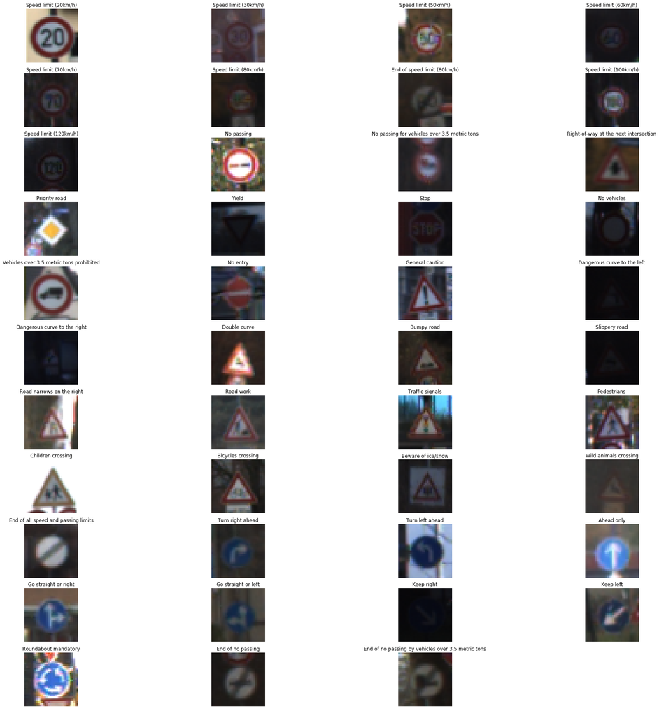

```python
show_images(X_train, y_train)
```

### Examining the distribution

There are 43 individual classes in our dataset. Below we are going to build up a merged histogram which includes the information of how many images there are in **training** and **validation** data sets

We create first the `panda` dictionaries for the data sets

```python
y_train_df = pd.DataFrame()
y_valid_df = pd.DataFrame()
y_train_df['label'] = y_train
y_valid_df['label'] = y_valid
```

And we plot the figure. The labels can be found on `x` axis whereas the amount of images for each corresponding label is on the `y` axis. The **training** and **validation** data sets!

[figure not shown]

```python
fig = plt.figure(figsize=(20,20))

train_chart = fig.add_subplot(111)
valid_chart = train_chart.twiny()

width = 0.7

train_handle = y_train_df['label'].value_counts().sort_index().plot(kind='bar', color='red',
                                                     ax = train_chart, width = width)
valid_handle = y_valid_df['label'].value_counts().sort_index().plot(kind='bar', color='blue',
                                                     ax = valid_chart, width = width)
train_chart.set_xticklabels(list(map(lambda x: label[x], y_train_df['label'].value_counts().index.tolist())),
                            rotation = 'vertical')

red_patch = mpatches.Patch(color='red', label='Training Data')
blue_patch = mpatches.Patch(color='blue', label='Validation Data')
plt.legend(handles=[red_patch, blue_patch],fontsize = 'x-large')

plt.show()
```

The difference in the amount of images between each label is obvious and the trend is the same in both sets (training and validation) it seems that the split is done with care to this. For the next step we need to take into account that this distribution will affect generalization of the model. Therefore we either have to augment the training dataset as some papers suggest or we use other techniques like spatial transformers to enhance generalization. Since data augmentation is rather straight-forward process I will proceed in using the spatial transformer networks as they are described in this [paper](https://arxiv.org/abs/1506.02025v3). Further description may be found below.

## Step 2: Design and Test a Model Architecture

Design and implement a deep learning model that learns to recognize traffic signs. Train and test your model on the [German Traffic Sign Dataset](http://benchmark.ini.rub.de/?section=gtsrb&subsection=dataset).

The LeNet-5 implementation shown in the classroom at the end of the CNN lesson is a solid starting point. You'll have to change the number of classes and possibly the preprocessing, but aside from that it's plug and play!

With the LeNet-5 solution from the lecture, you should expect a validation set accuracy of about 0.89. To meet specifications, the validation set accuracy will need to be at least 0.93. It is possible to get an even higher accuracy, but 0.93 is the minimum for a successful project submission.

There are various aspects to consider when thinking about this problem:

- Neural network architecture (is the network over or underfitting?)
- Play around preprocessing techniques (normalization, rgb to grayscale, etc)
- Number of examples per label (some have more than others).
- Generate fake data.

Here is an example of a [published baseline model on this problem](http://yann.lecun.com/exdb/publis/pdf/sermanet-ijcnn-11.pdf). It's not required to be familiar with the approach used in the paper but, it's good practice to try to read papers like these.

### Pre-process the Data Set (normalization, grayscale, etc.)

Minimally, the image data should be normalized so that the data has mean zero and equal variance. For image data, `(pixel - 128)/ 128` is a quick way to approximately normalize the data and can be used in this project.

Other pre-processing steps are optional. You can try different techniques to see if it improves performance.

Use the code cell (or multiple code cells, if necessary) to implement the first step of your project.

```python
### Preprocess the data here. It is required to normalize the data. Other preprocessing steps could include
### converting to grayscale, etc.
### Feel free to use as many code cells as needed.
### Import the necessary libraries
from skimage import exposure
import os
import warnings
from tqdm import tqdm
import cv2
```

#### Normalize Data

We tried different implementation regarding normalization during the investigation of the dataset. After many attempts on network training the changing to YUV colormap with global contrast normalization across Y channel as it is described on this [paper](http://yann.lecun.com/exdb/publis/pdf/sermanet-ijcnn-11.pdf) gave the best results. The user can try and normalize with the different functions by changing the argument `norm_ftype` on calling the `normalize` function.

#### Normalize helper functions

All the helper functions used in the exercise during investigation

```python
def adapt_hist(image_data):
    """
    Normalize images using built in equalize_adapthist function
    """
    with warnings.catch_warnings():
        warnings.simplefilter("ignore")
        return np.array([exposure.equalize_adapthist(image, clip_limit=0.03)
                         for image in tqdm(image_data)])

def clahe(image_data):
    """
    Normalize images using CLAHE algorithm of openCV
    """
    clahe = cv2.createCLAHE(clipLimit=0.0003, tileGridSize=(32,32))
    if image_data.ndim < 4:
         return np.array([clahe.apply(img) for img in tqdm(image_data)])
    else:
        gray = np.array([cv2.cvtColor(img, cv2.COLOR_RGB2GRAY) for img in
                                       image_data])
        return np.array([clahe.apply(img) for img in tqdm(gray)])

def simple_norm(image_data):
    """
    Simple normalization of pixels
    """
    image_data = np.array([cv2.cvtColor(img, cv2.COLOR_RGB2GRAY) for img in
                                       image_data])
    image_data = [((img - np.mean(img)) / np.std(img)) for img in image_data]


    return image_data

def yuv_ynorm_globalcontr(image_data, s=1, lamda=10, epsilon=0.000000001):
    """
    Change the color map to YUV and normalize using global contrast normalization
    across Y channel according to http://yann.lecun.com/exdb/publis/pdf/sermanet-ijcnn-11.pdf
    """
    conv_images = []
    image_data = np.array([cv2.cvtColor(img, cv2.COLOR_RGB2YUV) for img in image_data])
    for img in image_data:
        y = img[:,:,0]
        u = img[:,:,1]
        v = img[:,:,2]

        y = (y - np.mean(y))
        contrast = np.sqrt(lamda + np.mean(y**2))

        y = s * y / max(contrast, epsilon)

        conv_images.append(np.stack((y, u, v), axis=2))

    return conv_images

def yuv_ynorm_image(image_data):
    """
    Change the colormap to YUV and normalize across Y channel according to
    http://yann.lecun.com/exdb/publis/pdf/sermanet-ijcnn-11.pdf
    """
    conv_images = []
    image_data = np.array([cv2.cvtColor(img, cv2.COLOR_RGB2YUV) for img in image_data])
    for img in image_data:
        y = img[:,:,0]
        u = img[:,:,1]
        v = img[:,:,2]

        y = (y - np.mean(y)) / np.std(y)
        conv_images.append(np.stack((y, u, v), axis=2))
    return conv_images

def normalize(features, norm_ftype):
    data = {}
    print("\nNormalizing Set...")
    exec("data['features'] = "+norm_ftype+'(features)')
    return np.array(data['features'])
```

#### Create the file names

The train file is split as it couldn't be processed as a whole on the test PC with 16GB RAM. A workaround indicated on the internet for pickle files, is to split them into smaller ones. The `normalization` flag is used to enforce normalization even if the files already exist in the system.

```python
norm_training_file1  = './data/train_norm1.p'
norm_training_file2  = './data/train_norm2.p'
norm_validation_file = './data/valid_norm.p'
norm_testing_file    = './data/test_norm.p'

norm_type = 'yuv_ynorm_globalcontr'
normalization = True
```

#### Normalize and save the dataset

```python
if not os.path.isfile(norm_training_file1) or not os.path.isfile(norm_training_file2) or normalization:
    #X_train, y_train = load_data(resized_training_file)
    X_train1, X_train2 = np.array_split(X_train, 2)
    y_train1, y_train2 = np.array_split(y_train, 2)
    X_train_norm1 = normalize(X_train1, norm_type)
    save_data(norm_training_file1, X_train_norm1, y_train1)
    X_train_norm2 = normalize(X_train2, norm_type)
    save_data(norm_training_file2, X_train_norm2, y_train2)

if not os.path.isfile(norm_validation_file) or normalization:
    #X_valid, y_valid = load_data(resized_validation_file)
    X_valid_norm = normalize(X_valid, norm_type)
    save_data(norm_validation_file, X_valid_norm, y_valid)

if not os.path.isfile(norm_testing_file) or normalization:
    #X_test, y_test   = load_data(resized_testing_file)
    X_test_norm = normalize(X_test,  norm_type)
    save_data(norm_testing_file, X_test_norm, y_test)
```

```
Normalizing Set...

Saving Data...

Saved Data!

Normalizing Set...

Saving Data...

Saved Data!

Normalizing Set...

Saving Data...

Saved Data!

Normalizing Set...

Saving Data...

Saved Data!
```

#### Checkpoint: Load normalized images from files

Another checkpoint as we load now to our `X` and `y` variables the **normalized** data.

```python
X_train1, y_train1 = load_data(norm_training_file1)
X_train2, y_train2 = load_data(norm_training_file2)

y_train = np.append(y_train1, y_train2)

X_train = np.append(X_train1, X_train2, axis=0)

X_valid, y_valid = load_data(norm_validation_file)
X_test, y_test   = load_data(norm_testing_file)
```

#### Show normalized images

Again make sure that everything is O.K.

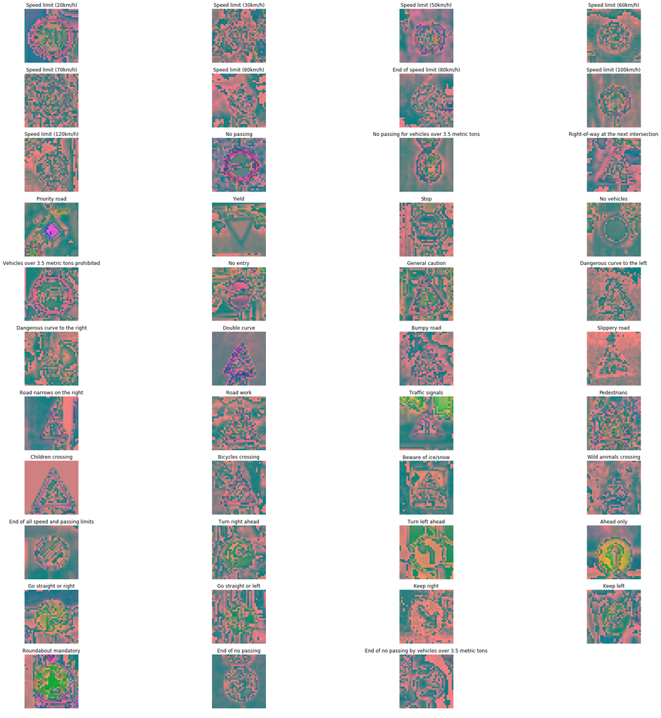

```python
show_images(X_train, y_train)
```

### Model Architecture

The Model architecture is mostly inspired by [Haloi's paper](https://arxiv.org/pdf/1511.02992.pdf), with some differentiation e.g in preprocessing method. We use the same number of Spatial Transformers and the inception network as it is described on the paper. The model and the layers can be found on the link. We used the [ST implementation](https://github.com/tensorflow/models/blob/master/research/transformer/spatial_transformer.py) found in Tensorflow models. The localization networks as well as the inception layers are built below.

#### Import libraries

```python
import tensorflow as tf
from tensorflow.contrib.layers import flatten, batch_norm
from spatial_transformer import transformer #from Tensorflow models
from sklearn.utils import shuffle
```

#### Reshape datasets

It is important to reshape them so we have a 4D arrays. The **channel number** shall be changed from 3 to 1 if a normalization using grayscale is used

```python
X_train = X_train.reshape([-1, 32, 32, 3])
X_valid = X_valid.reshape([-1, 32, 32, 3])
X_test  = X_test.reshape([-1, 32,  32, 3])
```

#### Import weight shapes

For the sake of keeping the notebook clean the initialized shapes of all weights and biases are kept in python scripts which are loaded below

```python
%run -i -n inception_W_shapes.py
%run -i -n inception_b_shapes.py
%run -i -n loc_W_shapes.py
%run -i -n loc_b_shapes.py
```

#### Helper Functions

Below all the functions are defined that help in building the neural network

##### Fundamental

Here are the fundamental functions that are used. Implementation for convolutions with or w/o activation maxpooling and linear multiplications. They will be used to build the more complex part of the network.

```python
def conv2d(x, W_shape, b_shape, stride=1, padding='SAME'):
    """
    Apply convolution with given W and b shapes
    """
    #Get Variables
    W = tf.get_variable("Wc", shape=W_shape,
                        initializer=tf.truncated_normal_initializer(mean=0, stddev=0.1))
    b = tf.get_variable("bc", shape=b_shape,
                        initializer=tf.constant_initializer(0.0))
    conv = tf.nn.conv2d(x, W, strides=[1, stride, stride, 1], padding=padding)
    conv = tf.nn.bias_add(conv, b)

    return conv

def conv2d_relu(x, W_shape, b_shape, stride=1, padding='SAME'):
    """
    Apply convolution, batch normalization and RELU activation
    """
    conv = batch_norm(conv2d(x, W_shape, b_shape, stride, padding),decay=0.9, zero_debias_moving_mean=True)
    return tf.nn.relu(conv)


def maxpool2d(x, k=2, stride=2, padding='VALID'):
    """
    Apply maxpooling with givven filter and stride
    """
    return tf.nn.max_pool(x, ksize=[1, k, k, 1], strides=[1, stride, stride, 1],
                         padding=padding)

def linear_logits(x, W_shape, b_shape):
    """
    Apply linear multiplication
    """
    #Get Variables
    W = tf.get_variable("Wlog", shape=W_shape,
                        initializer=tf.truncated_normal_initializer(mean=0, stddev=0.1))
    b = tf.get_variable("blog", shape=b_shape,
                        initializer=tf.constant_initializer(0.0))
    linear = tf.add(tf.matmul(x, W), b)
    return linear

def linear_relu(x, W_shape, b_shape):
    """
    Apply linear multiplication and RELU activation
    """
    linear = batch_norm(linear_logits(x, W_shape, b_shape), decay=0.9, zero_debias_moving_mean=True)
    return tf.nn.relu(linear)

def loc_logits(x, W_shape, b_shape):
    """
    Linear multiplication for localization network last layer.
    Theta 3x3 and initialized to identity """
    initial = np.array([[1.0, 0, 0], [0, 1.0, 0]])
    initial = initial.astype('float32')
    initial = initial.flatten()

    W = tf.get_variable("Wlog", shape=W_shape, initializer=tf.zeros_initializer())
    b = tf.get_variable("blog", shape=b_shape, initializer=tf.constant_initializer(initial))

    return tf.add(tf.matmul(x, W), b)
```

##### Localisation Networks

```python
def locNet1(x, W, b, name='loc1'):
    """
    Localization network 1
    """
    with tf.variable_scope(name+'_conv1'):
        pool1 = conv2d_relu(x, W['wc1'], b['bc1'], stride=2, padding='SAME')
        pool1 = maxpool2d(pool1, k=2, stride=2, padding='SAME')
    with tf.variable_scope(name+'_conv2'):
        pool2 = conv2d_relu(pool1, W['wc2'], b['bc2'], stride=2, padding='SAME')
        pool2 = maxpool2d(pool2, k=2, stride=2, padding='SAME')
    with tf.variable_scope(name+'_fc1'):
        f0 = flatten(pool2)
        f1 = tf.nn.dropout(linear_relu(f0, W['wd1'], b['bd1']), loc_fc1_keepprob)
    with tf.variable_scope(name+'_out'):
        out = loc_logits(f1, W['out'], b['out'])
    return out

def locNet3(x, W, b, name='loc3'):
    """
    Localization network 3
    """
    with tf.variable_scope(name+'_conv1'):
        pool1 = conv2d_relu(x, W['wc1'], b['bc1'], stride=2, padding='SAME')
    with tf.variable_scope(name+'_conv2'):
        pool2 = conv2d_relu(pool1, W['wc2'], b['bc2'], stride=1, padding='SAME')
        pool2 = maxpool2d(pool2, k=2, stride=2, padding='SAME')
    with tf.variable_scope(name+'_fc1'):
        f0 = flatten(pool2)
        f1 = tf.nn.dropout(linear_relu(f0, W['wd1'], b['bd1']), loc_fc1_keepprob)
    with tf.variable_scope(name+'_out'):
        out = loc_logits(f1, W['out'], b['out'])
    return out
```

#### Spatial Transformers

```python
def st1(x, W_shape, b_shape, out_dims):
    """
    Spatial Transformer 1
    """
    theta = locNet1(x, W_shape, b_shape, name='loc1')
    x_t = transformer(x, theta, out_dims)
    return x_t, theta

def st3(x, W_shape, b_shape, out_dims):
    """
    Spatial Transformer 3
    """
    theta = locNet3(x, W_shape, b_shape, name='loc3a')
    x_t = transformer(x, theta, out_dims)
    return x_t, theta

def st4(x, W_shape, b_shape, out_dims):
    """
    Spatial Transformer 4
    """
    theta = locNet3(x, W_shape, b_shape, name='loc3b')
    x_t = transformer(x, theta, out_dims)
    return x_t, theta
```

##### Inception

The implementation of inception network. The main function builds up the inception and the function below each stage of the inception network

```python
def inception(x, W, b, name='inception'):
    """
    The basis implementation of the inception layer
    """
    # Convolution 1x1
    with tf.variable_scope(name+'_conv1x1'):
        conv1x1 = conv2d_relu(x, W['w1x1'], b['b1x1'], stride=1, padding='SAME')
        tf.nn.dropout(conv1x1, inception_int_keepprob)
    # Layer 2: Convolution 1x1 and 3x3
    with tf.variable_scope(name+'_conv3x3red'):
        conv3x3red = conv2d_relu(x, W['w3x3red'], b['b3x3red'], stride=1, padding='SAME')
    with tf.variable_scope(name+'_con3x3'):
        conv3x3 = conv2d_relu(conv3x3red, W['w3x3'], b['b3x3'], stride=1, padding='SAME')
        tf.nn.dropout(conv3x3, inception_int_keepprob)
    # Layer 3: Convolution 1x1 and 5x5
    with tf.variable_scope(name+'_conv5x5red'):
        conv5x5red = conv2d_relu(x, W['w5x5red'], b['b5x5red'], stride=1, padding='SAME')
    with tf.variable_scope(name+'_conv5x5'):
        conv5x5 = conv2d_relu(conv5x5red, W['w5x5'], b['b5x5'], stride=1, padding='SAME')
        tf.nn.dropout(conv5x5, inception_int_keepprob)
    # Layer 4: Convolution 1x1, 3x3 and Max Pooling 3x3
    with tf.variable_scope(name+'_pool3x3red'):
        conv3x3redp = conv2d_relu(x, W['w3x3redp'], b['b3x3redp'], stride=1, padding='SAME')
    with tf.variable_scope(name+'_pool3x3'):
        conv3x3p = conv2d_relu(conv3x3redp, W['w3x3p'], b['b3x3p'], stride=1, padding='SAME')
        max3x3 = maxpool2d(conv3x3p, k=3, stride=1, padding='SAME')
        tf.nn.dropout(max3x3, inception_int_keepprob)
    # Filter Concatenation
    output = tf.concat([conv1x1, conv3x3, conv5x5, max3x3], 3)

    return output
```

```python
def inception3(x):
    """
    Inception Intermediate Layers 3a and 3b
    In the middle there is an ST implemented
    """
    # Inception Layer 3a: Input = 16x16x192, Output = 16x16x288
    with tf.name_scope('inception3a'):
        inception3a = inception(x, inceptNet3a_W, inceptNet3a_b, name='inception3a')

    with tf.name_scope('stn4'):
        inception3a_t, theta = st4(inception3a, locNet4_W, locNet4_b, (16, 16))

    # Inception Layer 3b: Input = 16x16x288, Output = 16x16x480
    with tf.name_scope('inception3b'):
        inception3b = inception(inception3a_t, inceptNet3b_W, inceptNet3b_b, name='inception3b')
    return tf.nn.dropout(inception3b,inception_keepprob), inception3a_t, theta

def inception4(x):
    """
     Inception Intermediate Layers 4a, 4b, 4c, 4d, 4e
    """
    # Inception 4a: Input = 8x8x480, Output = 8x8x512
    with tf.name_scope('inception4a'):
        inception4a = inception(x, inceptNet3_W, inceptNet3_b, name='inception4a')
    # Inception 4b: Input = 8x8x512, Output = 8x8x512 (4b)
    with tf.name_scope('inception4b'):
        inception4b = inception(inception4a, inceptNet4_W, inceptNet4_b, name='inception4b')
    # Inception 4c: Input = 8x8x512, Output = 8x8x512 (4c)
    with tf.name_scope('inception4c'):
        inception4c = inception(inception4b, inceptNet5_W, inceptNet5_b, name='inception4c')
    # Inception 4d: Input = 8x8x512, Output = 8x8x528 (4d)
    with tf.name_scope('inception4d'):
        inception4d = inception(inception4c, inceptNet6_W, inceptNet6_b, name='inception4d')
    # Inception 4e: Input = 8x8x528, Output = 8x8x832 (4e)
    with tf.name_scope('inception4e'):
        inception4e = inception(inception4d, inceptNet7_W, inceptNet7_b, name='inception4e')
    return tf.nn.dropout(inception4e,inception_keepprob)

def inception5(x):
    """
    Inception Intermediate layers 5a and 5b
    """
    # Inception 5a: Input = 4x4x832, Output = 4x4x832 (5a)
    with tf.name_scope('inception5a'):
        inception5a = inception(x, inceptNet8_W, inceptNet8_b, name='inception5a')
    # Inception 5b: Input = 4x4x832, Output = 4x4x1024 (5b)
    with tf.name_scope('inception5b'):
        inception5b = inception(inception5a, inceptNet9_W, inceptNet9_b, name='inception5b')
    return tf.nn.dropout(inception5b,inception_keepprob)
```

#### Main Network

The main network using the STs inception and the extra convolution maxpooling and full layers.

```python
Net_W = {
    'wc1': [5, 5, 3, 64],
    'wc2': [3, 3, 64, 192],
    'wd1': [1*1*1024, n_classes],
}
Net_b = {
    'bc1': [Net_W['wc1'][3]],
    'bc2': [Net_W['wc2'][3]],
    'bd1': [Net_W['wd1'][1]],
}

def Net(x):
    """
    Complete neural net buildup
    """
    with tf.name_scope('local_norm'):
        #x_norm = tf.nn.lrn(x, depth_radius=5, bias=2, alpha=0.0001, beta=0.75)
        x_norm = batch_norm(x)
    # Spatial Transformation
    with tf.name_scope('stn1'):
        x_t, theta1 = st1(x_norm, locNet1_W, locNet1_b, (128, 128))

    # Layer 1: Convolutional. Input = 128x128xC, Output = 64x64x64.
    with tf.variable_scope('conv1'):
        conv1 = conv2d_relu(x_t, Net_W['wc1'], Net_b['bc1'], stride=2, padding='SAME')

    # Pooling. Input = 64x64x64, Output = 32x32x64.
    conv1 = maxpool2d(conv1, k=3, stride=2, padding='SAME')

    # Layer 2: Convolutional. Input = 32x32x64, Output = 32x32x192.
    with tf.variable_scope('conv2'):
        conv2 = conv2d_relu(conv1, Net_W['wc2'], Net_b['bc2'], stride=1, padding='SAME')

    # Pooling. Input = 32x32x192. Output = 16x16x192.
    conv2 = maxpool2d(conv2, k=3, stride=2, padding='SAME')

    # Spatial Transformation
    with tf.name_scope('stn3'):
        conv2_t, theta2 = st3(conv2, locNet3_W, locNet3_b, (16, 16))

    ### Inception Layers ###
    inceptionL3, inception3a_t, theta3 = inception3(conv2_t)

    inceptionL3 = maxpool2d(inceptionL3, k=3, stride=2)

    inceptionL4 = inception4(inceptionL3)

    net = maxpool2d(inceptionL4, k=3, stride=2, padding='SAME')

    inceptionL5 = inception5(net)

    ### End of Inception Layers ###

    # Pooling: Input = 4x4x1024, Output = 1x1x1024
    avg_pool = tf.nn.avg_pool(inceptionL5, ksize=[1, 4, 4, 1], strides = [1, 4, 4, 1], padding='SAME')

    # Dropout: Input = 1x1x1024, Output = 1x1x1024
    drop_out = tf.nn.dropout(avg_pool, fc1_keepprob)

    # Flatten. Input = 1x1x1024. Output = 1024.
    f0 = flatten(drop_out)

    # Fully Connected. Input = 1024. Output = 43.
    with tf.variable_scope('logits'):
        logits = linear_logits(f0, Net_W['wd1'], Net_b['bd1'])

    return logits, x_t, theta1, conv1, conv2, conv2_t, theta2, inceptionL3, inception3a_t, theta3, inceptionL4, inceptionL5, f0
```

#### Loss Function

```python
def calc_loss(logits, one_hot_y):
    with tf.name_scope('Predictions'):
        predictions = tf.nn.softmax(logits)
    with tf.name_scope('Cross_Entropy'):
        cross_entropy = tf.nn.softmax_cross_entropy_with_logits(logits=logits, labels=one_hot_y)
    with tf.name_scope('Loss'):
        loss_operation = tf.reduce_mean(cross_entropy)
    return loss_operation
```

#### Network configuration

Image shape, batch size, epochs and learning rate are configured here

```python
CONFIG = {
    'H' : 32,
    'W' : 32,
    'C' : 3,
    'batch_size' : 20,
    'EPOCHS' :100,
    'lr' : 0.00032

}
```

```python
# Clear the graph
tf.reset_default_graph()
```

#### Features and Labels

`x` is a placeholder for a batch of input images. `y` is a placeholder for a batch of output labels.

```python
with tf.name_scope('batch'):
    x = tf.placeholder(tf.float32, (None, CONFIG['H'], CONFIG['W'], CONFIG['C']), name='InputImages')
    y = tf.placeholder(tf.int32, (None), name='InputLabels')
    one_hot_y = tf.one_hot(y, n_classes, name='InputLabelsOneHot')
```

#### Dropout Placeholders

```python
with tf.name_scope('dropout'):
    loc_fc1_keepprob = tf.placeholder(tf.float32, name='loc_fc1_do')
    loc_fc2_keepprob = tf.placeholder(tf.float32, name='loc_fc2_do')
    inception_keepprob = tf.placeholder(tf.float32, name='inception_do')
    fc1_keepprob = tf.placeholder(tf.float32, name='fc1_do')
    inception_int_keepprob = tf.placeholder(tf.float32, name='inception_int_do')
```

#### Initialize Net

```python
with tf.name_scope('logits'):
    logits, x_t, theta1, conv1, conv2, conv2_t, theta2, inceptionL3, inception3a_t, theta3, inceptionL4, inceptionL5, f0 = Net(x)
```

#### Prediction and Accuracy

```python
with tf.name_scope('correct_prediction'):
    correct_prediction = tf.equal(tf.argmax(logits, 1), tf.argmax(one_hot_y, 1))
    corr_pred_numval = tf.cast(correct_prediction, tf.float32)

with tf.name_scope('accuracy'):
    accuracy_operation = tf.reduce_mean(corr_pred_numval)
```

#### Loss Operation

```python
with tf.name_scope('calc_loss'):
    loss_operation = calc_loss(logits, one_hot_y)
```

#### Learning Rate

```python
starter_rate = tf.placeholder(tf.float32, name='lr')
global_step = tf.Variable(0, trainable=False, name='g_step')
steps = round(len(X_train) / CONFIG['batch_size'])
bounds = [round(25*steps), round(40*steps), round(65*steps),
          round(85*steps),round(95*steps)]
values = [0.00032, 0.00015, 0.00010, 0.00007, 0.000035, 0.000015]
learning_rate = tf.train.piecewise_constant(global_step, bounds, values)
```

#### Optimization

```python
with tf.name_scope('optimizer'):
#    optimizer = tf.train.RMSPropOptimizer(learning_rate = learning_rate,
#                                          decay=0.0918, momentum=0.9)
    optimizer = tf.train.AdamOptimizer(learning_rate=learning_rate)
```

#### Backpropagation

```python
with tf.name_scope('backpropagation'):
    training_operation = optimizer.minimize(loss_operation, global_step=global_step)
```

### Train, Validate and Test the Model

A validation set can be used to assess how well the model is performing. A low accuracy on the training and validation sets imply underfitting. A high accuracy on the training set but low accuracy on the validation set implies overfitting.

```python
EPOCHS = CONFIG['EPOCHS']
BATCH_SIZE = CONFIG['batch_size']
```

#### Model Evaluation

```python
def evaluate(X_data, y_data, batch_size=1280):
    """
    Helper function to evaluate the network on given data
    """
    num_examples = len(X_data)
    total_accuracy = 0
    total_loss = []
    sess = tf.get_default_session()

    for offset in range(0, num_examples, batch_size):
        batch_x, batch_y = X_data[offset:offset+batch_size], y_data[offset:offset+batch_size]

        batch_accuracy, batch_loss = sess.run([accuracy_operation, loss_operation],
                                              feed_dict={x: batch_x,
                                                         y: batch_y,
                                                         loc_fc1_keepprob: 1.0,
                                                         loc_fc2_keepprob: 1.0,
                                                         inception_keepprob: 1.0,
                                                         fc1_keepprob: 1.0,
                                                         inception_int_keepprob: 1.0
                                                        })

        total_accuracy += (batch_accuracy * len(batch_x))
        total_loss.append(batch_loss)

    return total_accuracy / num_examples, np.average(total_loss)
```

```python
def checking(X_train, y_train, X_valid, y_valid, batch, train_sum, valid_sum):
    """
    Helper function to check information during training
    """
    x_train_batch, y_train_batch = shuffle(X_train, y_train)
    x_train_batch, y_train_batch = x_train_batch[:BATCH_SIZE], y_train_batch[:BATCH_SIZE]

    #Evaluate validation data:
    accuracy, loss = evaluate(X_valid, y_valid)

    #Run for only one batch from training set
    b_train_acc, summary = sess.run([accuracy_operation, summary_op],
                                 feed_dict={
                                     x: x_train_batch,
                                     y: y_train_batch,
                                     loc_fc1_keepprob: 1.0,
                                     loc_fc2_keepprob: 1.0,
                                     inception_keepprob: 1.0,
                                     inception_int_keepprob: 1.0,
                                     fc1_keepprob: 1.0})
    train_sum.add_summary(summary, batch)

    # Compare on one batch from valid set
    x_valid_batch, y_valid_batch = shuffle(X_valid, y_valid)
    x_valid_batch, y_valid_batch = x_valid_batch[:BATCH_SIZE], y_valid_batch[:BATCH_SIZE]
    b_valid_acc, summary = sess.run([accuracy_operation, summary_op],
                                   feed_dict={
                                   x: x_valid_batch,
                                   y: y_valid_batch,
                                   loc_fc1_keepprob: 1.0,
                                   loc_fc2_keepprob: 1.0,
                                   inception_keepprob: 1.0,
                                   inception_int_keepprob: 1.0,
                                   fc1_keepprob: 1.0})
    valid_sum.add_summary(summary, batch)

    print("Batch {}: Val_Acc = {:.3f}, Val_Loss = {:.6f}, LR = {:.6f} Batch_Val_Acc = {:.3f}, Batch_Train_Acc = {:.3f}".
          format(batch, accuracy, loss, lr, b_valid_acc, b_train_acc))
```

#### Training Pipeline

```python
tf.summary.scalar("loss", loss_operation)
tf.summary.scalar("accuracy", accuracy_operation)
summary_op = tf.summary.merge_all()

saver = tf.train.Saver(max_to_keep=3)
```

```python
with tf.Session() as sess:
    sess.run(tf.global_variables_initializer())
    train_sum = tf.summary.FileWriter("./model/train", sess.graph)
    valid_sum = tf.summary.FileWriter("./model/valid", sess.graph)
    num_examples = len(X_train)
    val_acc = []
    val_acc.append(0)
    print("Training...")
    print()
    batch_no = 0
    for i in range(EPOCHS):
        X_train, y_train = shuffle(X_train, y_train)
        for offset in range(0, num_examples, BATCH_SIZE):

            end = offset + BATCH_SIZE
            batch_x, batch_y = X_train[offset:end], y_train[offset:end]
            _, loss, lr = sess.run([training_operation, loss_operation, learning_rate],
                                   feed_dict={x: batch_x,
                                              y: batch_y,
                                              loc_fc1_keepprob: 0.8,
                                              loc_fc2_keepprob: 0.7,
                                              inception_keepprob: 0.6,
                                              inception_int_keepprob: 1.0,
                                              fc1_keepprob: 0.4,
                                              starter_rate: CONFIG['lr']})
            if batch_no % 500 == 0:
                checking(X_train, y_train, X_valid, y_valid, batch_no, train_sum, valid_sum)
            batch_no += 1

        train_accuracy, train_loss = evaluate(X_train, y_train)
        valid_accuracy, valid_loss = evaluate(X_valid, y_valid)
        val_acc.append(valid_accuracy)
        print("EPOCH {} ...".format(i+1))
        print("LR = {:.6f}".format(lr))
        print("Training Accuracy = {:.3f}, Train Loss = {:.6f}".
              format(train_accuracy, train_loss))
        print("Validation Accuracy = {:.3f}, Valid Loss = {:.6f}".
              format(valid_accuracy, valid_loss))
        print()
        if val_acc[-1] > val_acc[-2]:
            saver.save(sess, './model/Net_Epoch_{}_acc_{:.3f}'.format(i+1, val_acc[-1]))
            print("Model saved")
            print()
        else:
            del val_acc[-1]

    saver.save(sess, './model/Net_Epoch_{}_acc_{:.3f}'.format(i+1, valid_accuracy))
    print("Model saved - Last Epoch")
    print()
```

```
Training...

Batch 0: Val_Acc = 0.015, Val_Loss = 5.563493, LR = 0.000320 Batch_Val_Acc = 0.000, Batch_Train_Acc = 0.000
Batch 500: Val_Acc = 0.158, Val_Loss = 3.524119, LR = 0.000320 Batch_Val_Acc = 0.100, Batch_Train_Acc = 0.200
Batch 1000: Val_Acc = 0.199, Val_Loss = 2.956939, LR = 0.000320 Batch_Val_Acc = 0.300, Batch_Train_Acc = 0.350
Batch 1500: Val_Acc = 0.304, Val_Loss = 2.607759, LR = 0.000320 Batch_Val_Acc = 0.300, Batch_Train_Acc = 0.550
EPOCH 1 ...
LR = 0.000320
Training Accuracy = 0.529, Train Loss = 1.491086
Validation Accuracy = 0.337, Valid Loss = 2.353662

Model saved

Batch 2000: Val_Acc = 0.373, Val_Loss = 2.204741, LR = 0.000320 Batch_Val_Acc = 0.600, Batch_Train_Acc = 0.450
Batch 2500: Val_Acc = 0.465, Val_Loss = 1.959683, LR = 0.000320 Batch_Val_Acc = 0.550, Batch_Train_Acc = 0.450
Batch 3000: Val_Acc = 0.619, Val_Loss = 1.571397, LR = 0.000320 Batch_Val_Acc = 0.800, Batch_Train_Acc = 0.750
EPOCH 2 ...
LR = 0.000320
Training Accuracy = 0.889, Train Loss = 0.342178
Validation Accuracy = 0.677, Valid Loss = 1.626129

Model saved

Batch 3500: Val_Acc = 0.696, Val_Loss = 1.576594, LR = 0.000320 Batch_Val_Acc = 0.800, Batch_Train_Acc = 0.800
Batch 4000: Val_Acc = 0.744, Val_Loss = 1.299209, LR = 0.000320 Batch_Val_Acc = 0.750, Batch_Train_Acc = 0.850
Batch 4500: Val_Acc = 0.811, Val_Loss = 0.779316, LR = 0.000320 Batch_Val_Acc = 0.950, Batch_Train_Acc = 1.000
Batch 5000: Val_Acc = 0.851, Val_Loss = 0.742875, LR = 0.000320 Batch_Val_Acc = 0.900, Batch_Train_Acc = 1.000
EPOCH 3 ...
LR = 0.000320
Training Accuracy = 0.962, Train Loss = 0.129652
Validation Accuracy = 0.804, Valid Loss = 0.991906

Model saved

Batch 5500: Val_Acc = 0.870, Val_Loss = 0.783869, LR = 0.000320 Batch_Val_Acc = 0.800, Batch_Train_Acc = 0.900
Batch 6000: Val_Acc = 0.869, Val_Loss = 0.756754, LR = 0.000320 Batch_Val_Acc = 0.800, Batch_Train_Acc = 1.000
Batch 6500: Val_Acc = 0.837, Val_Loss = 0.853041, LR = 0.000320 Batch_Val_Acc = 0.950, Batch_Train_Acc = 0.950
EPOCH 4 ...
LR = 0.000320
Training Accuracy = 0.985, Train Loss = 0.044470
```

[output cut: 834 more lines]

```
Batch 172000: Val_Acc = 0.985, Val_Loss = 0.146666, LR = 0.000015 Batch_Val_Acc = 1.000, Batch_Train_Acc = 1.000
EPOCH 99 ...
LR = 0.000015
Training Accuracy = 1.000, Train Loss = 0.000002
Validation Accuracy = 0.985, Valid Loss = 0.145783

Batch 172500: Val_Acc = 0.985, Val_Loss = 0.144830, LR = 0.000015 Batch_Val_Acc = 0.950, Batch_Train_Acc = 1.000
Batch 173000: Val_Acc = 0.985, Val_Loss = 0.140631, LR = 0.000015 Batch_Val_Acc = 1.000, Batch_Train_Acc = 1.000
Batch 173500: Val_Acc = 0.984, Val_Loss = 0.142562, LR = 0.000015 Batch_Val_Acc = 0.900, Batch_Train_Acc = 1.000
EPOCH 100 ...
LR = 0.000015
Training Accuracy = 1.000, Train Loss = 0.000000
Validation Accuracy = 0.984, Valid Loss = 0.142595

Model saved - Last Epoch
```

#### Apply on Test Images

```python
with tf.Session() as sess:
    saver.restore(sess, tf.train.latest_checkpoint('./model/'))
    test_accuracy = evaluate(X_test, y_test)[0]
    print("Test Accuracy = {:.2f}%".format(test_accuracy*100.0))
```

```
INFO:tensorflow:Restoring parameters from ./model/Net_Epoch_90_acc_0.986
Test Accuracy = 98.67%
```

## Step 3: Test a Model on New Images

To give yourself more insight into how your model is working, download at least five pictures of German traffic signs from the web and use your model to predict the traffic sign type.

You may find `signnames.csv` useful as it contains mappings from the class id (integer) to the actual sign name.

### Load and Output the Images

In order to test the model a mixture of images from internet and also some pictures taken from my cellphone driving from home to work. I live in Germany so I assumed the sample will be of good use. I just cropped the images randomly to reduce their size and delberately set the position of the signs not exactly in the center to test the that the network is generalized well enough for signs located anywhere than the middle of the image

```python
import os, fnmatch

input_img_path = "./images/"
img_name_list = fnmatch.filter(os.listdir(input_img_path), '*.jpg')
img_list = []
images = np.array([np.array(plt.imread(os.path.join(input_img_path,name))) for name in img_name_list])
```

#### Prepare the labels of the list

```python
img_labels = np.array([11, 12, 14, 17, 18, 1, 22, 25, 28, 28, 29, 2, 35, 35, 36, 37, 38, 38, 38, 3, 41, 9], dtype=np.uint8)
```

#### Display images helper function

```python
def display_images(images, img_labels):
    """
    Given the images and the labes it displays the images
    """
    fig = plt.figure(figsize=(15,15))
    for i in range(len(images)):
        plt.subplot(len(images)//4+1,4,i+1)
        if images[i].ndim > 2:
            plt.imshow(images[i])
        else:
            plt.imshow(images[i], cmap = 'gray')
        plt.title(label[img_labels[i]])
        plt.axis('off')
```

[figure not shown]

```python
display_images(images, img_labels)
```

### Predict the Sign Type for Each Image

#### Preprocess the images

We use the same process of preprocessing as we did for the train dataset

```python
images = [cv2.resize(img, (32, 32), cv2.INTER_CUBIC) for img in images]
norm_imgs = normalize(features=images, norm_ftype=norm_type)
```

```
Normalizing Set...
```

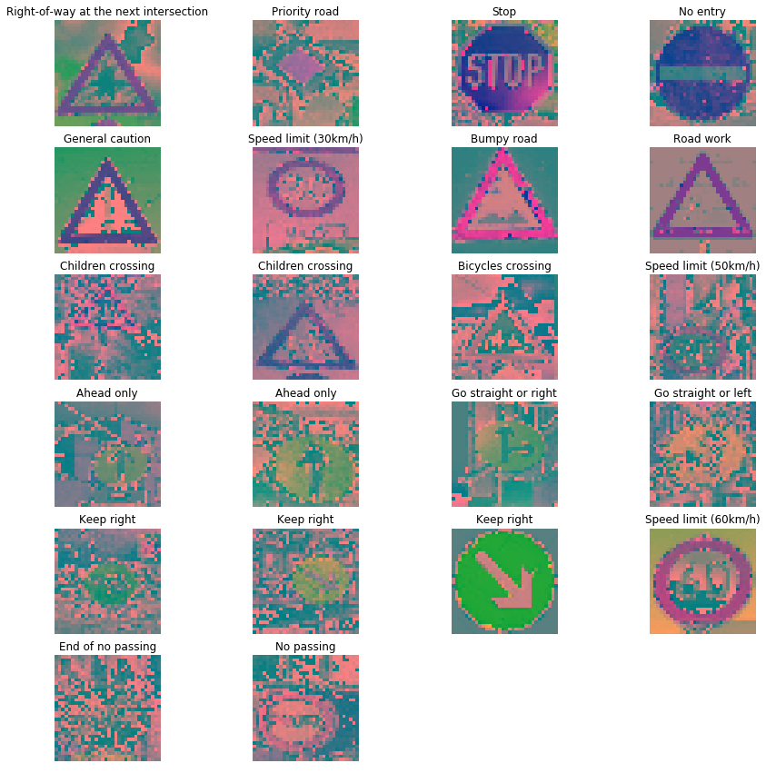

```python
display_images(norm_imgs, img_labels)
```

```python
norm_imgs = norm_imgs.reshape([-1, 32, 32, 3])
```

### Analyze Performance

```python
### Calculate the accuracy for these 5 new images.
### For example, if the model predicted 1 out of 5 signs correctly, it's 20% accurate on these new images.

with tf.Session() as sess:
    saver.restore(sess, tf.train.latest_checkpoint('./model/'))
    test_accuracy = evaluate(norm_imgs, img_labels, batch_size=23)[0]
    print("Test Accuracy = {:.1f}%".format(test_accuracy*100.0))
```

```
INFO:tensorflow:Restoring parameters from ./model/Net_Epoch_90_acc_0.986
Test Accuracy = 100.0%
```

The model managed to achieve 100% on the given extra images. This means it could work generally well on random images but only on this epoch No. 90. When I loaded epoch No100 which was the last the model was not capable to recognize all of them.

### Output Top 5 Softmax Probabilities For Each Image Found on the Web

For each of the new images, print out the model's softmax probabilities to show the **certainty** of the model's predictions (limit the output to the top 5 probabilities for each image). [`tf.nn.top_k`](https://www.tensorflow.org/versions/r0.12/api_docs/python/nn.html#top_k) could prove helpful here.

The example below demonstrates how tf.nn.top_k can be used to find the top k predictions for each image.

`tf.nn.top_k` will return the values and indices (class ids) of the top k predictions. So if k=3, for each sign, it'll return the 3 largest probabilities (out of a possible 43) and the correspoding class ids.

Take this numpy array as an example. The values in the array represent predictions. The array contains softmax probabilities for five candidate images with six possible classes. `tf.nn.top_k` is used to choose the three classes with the highest probability:

```
# (5, 6) array
a = np.array([[ 0.24879643,  0.07032244,  0.12641572,  0.34763842,  0.07893497,
         0.12789202],
       [ 0.28086119,  0.27569815,  0.08594638,  0.0178669 ,  0.18063401,
         0.15899337],
       [ 0.26076848,  0.23664738,  0.08020603,  0.07001922,  0.1134371 ,
         0.23892179],
       [ 0.11943333,  0.29198961,  0.02605103,  0.26234032,  0.1351348 ,
         0.16505091],
       [ 0.09561176,  0.34396535,  0.0643941 ,  0.16240774,  0.24206137,
         0.09155967]])
```

Running it through `sess.run(tf.nn.top_k(tf.constant(a), k=3))` produces:

```
TopKV2(values=array([[ 0.34763842,  0.24879643,  0.12789202],
       [ 0.28086119,  0.27569815,  0.18063401],
       [ 0.26076848,  0.23892179,  0.23664738],
       [ 0.29198961,  0.26234032,  0.16505091],
       [ 0.34396535,  0.24206137,  0.16240774]]), indices=array([[3, 0, 5],
       [0, 1, 4],
       [0, 5, 1],
       [1, 3, 5],
       [1, 4, 3]], dtype=int32))
```

Looking just at the first row we get `[ 0.34763842, 0.24879643, 0.12789202]`, you can confirm these are the 3 largest probabilities in `a`. You'll also notice `[3, 0, 5]` are the corresponding indices.

```python
### Print out the top five softmax probabilities for the predictions on the German traffic sign images found on the web.
### Feel free to use as many code cells as needed.
```

```python
with tf.Session() as sess:
    saver.restore(sess, tf.train.latest_checkpoint('./model/'))
    out_logits = sess.run(tf.nn.softmax(logits), feed_dict={x: norm_imgs[0:len(norm_imgs)],
                                                            loc_fc1_keepprob: 1.0,
                                                            loc_fc2_keepprob: 1.0,
                                                            inception_keepprob: 1.0,
                                                            fc1_keepprob: 1.0,
                                                            inception_int_keepprob: 1.0
                                                            })
    top_prob, top_pred = sess.run(tf.nn.top_k(tf.constant(out_logits), k=5))
```

```
INFO:tensorflow:Restoring parameters from ./model/Net_Epoch_90_acc_0.986
```

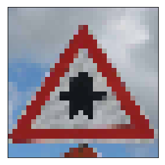

```
   11: Right-of-way at the next intersection              (100.0000000000%)
   10: No passing for vehicles over 3.5 metric tons       (  0.0000000001%)
    5: Speed limit (80km/h)                               (  0.0000000000%)
    1: Speed limit (30km/h)                               (  0.0000000000%)
   16: Vehicles over 3.5 metric tons prohibited           (  0.0000000000%)
```

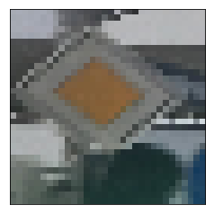

```
   12: Priority road                                      (100.0000000000%)
   13: Yield                                              (  0.0000000000%)
    2: Speed limit (50km/h)                               (  0.0000000000%)
    5: Speed limit (80km/h)                               (  0.0000000000%)
   10: No passing for vehicles over 3.5 metric tons       (  0.0000000000%)
```

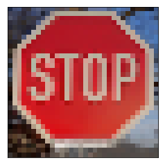

```
   14: Stop                                               (100.0000000000%)
    5: Speed limit (80km/h)                               (  0.0000003671%)
    4: Speed limit (70km/h)                               (  0.0000000339%)
   13: Yield                                              (  0.0000000086%)
    3: Speed limit (60km/h)                               (  0.0000000063%)
```

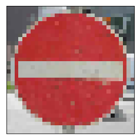

```
   17: No entry                                           (100.0000000000%)
    4: Speed limit (70km/h)                               (  0.0000000000%)
    7: Speed limit (100km/h)                              (  0.0000000000%)
   10: No passing for vehicles over 3.5 metric tons       (  0.0000000000%)
    3: Speed limit (60km/h)                               (  0.0000000000%)
```

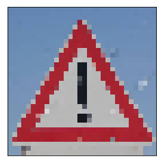

```
   18: General caution                                    (100.0000000000%)
   31: Wild animals crossing                              (  0.0000000000%)
    4: Speed limit (70km/h)                               (  0.0000000000%)
    5: Speed limit (80km/h)                               (  0.0000000000%)
   15: No vehicles                                        (  0.0000000000%)
```

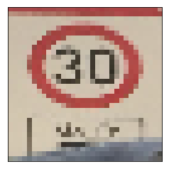

```
    1: Speed limit (30km/h)                               (100.0000000000%)
    5: Speed limit (80km/h)                               (  0.0000000000%)
    2: Speed limit (50km/h)                               (  0.0000000000%)
    3: Speed limit (60km/h)                               (  0.0000000000%)
    4: Speed limit (70km/h)                               (  0.0000000000%)
```

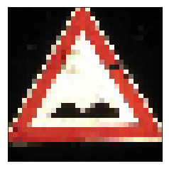

```
   22: Bumpy road                                         (100.0000000000%)
   25: Road work                                          (  0.0000000096%)
   26: Traffic signals                                    (  0.0000000082%)
   12: Priority road                                      (  0.0000000081%)
   30: Beware of ice/snow                                 (  0.0000000026%)
```

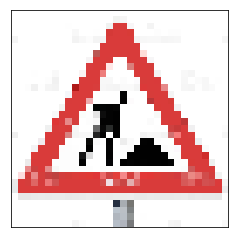

```
   25: Road work                                          (100.0000000000%)
    4: Speed limit (70km/h)                               (  0.0000000000%)
    8: Speed limit (120km/h)                              (  0.0000000000%)
   13: Yield                                              (  0.0000000000%)
    1: Speed limit (30km/h)                               (  0.0000000000%)
```

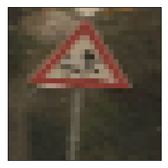

```
   28: Children crossing                                  ( 99.9491691589%)
   27: Pedestrians                                        (  0.0446010468%)
   11: Right-of-way at the next intersection              (  0.0034987152%)
   18: General caution                                    (  0.0011088750%)
    0: Speed limit (20km/h)                               (  0.0008985787%)
```

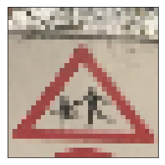

```
   28: Children crossing                                  (100.0000000000%)
   29: Bicycles crossing                                  (  0.0000034484%)
    8: Speed limit (120km/h)                              (  0.0000003242%)
   11: Right-of-way at the next intersection              (  0.0000001910%)
   30: Beware of ice/snow                                 (  0.0000001594%)
```

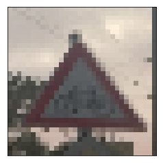

```
   29: Bicycles crossing                                  ( 99.9999523163%)
   13: Yield                                              (  0.0000347406%)
   15: No vehicles                                        (  0.0000050135%)
   22: Bumpy road                                         (  0.0000038752%)
   26: Traffic signals                                    (  0.0000030469%)
```

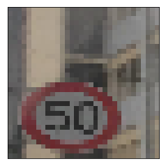

```
    2: Speed limit (50km/h)                               (100.0000000000%)
    7: Speed limit (100km/h)                              (  0.0000000017%)
    5: Speed limit (80km/h)                               (  0.0000000006%)
    3: Speed limit (60km/h)                               (  0.0000000001%)
    4: Speed limit (70km/h)                               (  0.0000000000%)
```

[10 more figures not shown]

```
    9: No passing                                         (100.0000000000%)
   10: No passing for vehicles over 3.5 metric tons       (  0.0000000000%)
    7: Speed limit (100km/h)                              (  0.0000000000%)
    8: Speed limit (120km/h)                              (  0.0000000000%)
   18: General caution                                    (  0.0000000000%)
```

```python
for i, (preds, probs, image) in enumerate(zip(top_pred, top_prob, images)):
    plt.imshow(image)
    plt.xticks([])
    plt.yticks([])
    plt.show()
    for pred, prob in zip(preds.astype(int), probs):
        sign_name = label[pred]
        print('{:>5}: {:<50} ({:>14.10f}%)'.format(pred, sign_name, prob*100.0))
    print("")
```

### Project Writeup

Once you have completed the code implementation, document your results in a project writeup using this [template](https://github.com/udacity/CarND-Traffic-Sign-Classifier-Project/blob/master/writeup_template.md) as a guide. The writeup can be in a markdown or pdf file.

## Step 4 (Optional): Visualize the Neural Network's State with Test Images

This Section is not required to complete but acts as an additional excersise for understaning the output of a neural network's weights. While neural networks can be a great learning device they are often referred to as a black box. We can understand what the weights of a neural network look like better by plotting their feature maps. After successfully training your neural network you can see what it's feature maps look like by plotting the output of the network's weight layers in response to a test stimuli image. From these plotted feature maps, it's possible to see what characteristics of an image the network finds interesting. For a sign, maybe the inner network feature maps react with high activation to the sign's boundary outline or to the contrast in the sign's painted symbol.

Provided for you below is the function code that allows you to get the visualization output of any tensorflow weight layer you want. The inputs to the function should be a stimuli image, one used during training or a new one you provided, and then the tensorflow variable name that represents the layer's state during the training process, for instance if you wanted to see what the LeNet lab's feature maps looked like for it's second convolutional layer you could enter conv2 as the tf_activation variable.

For an example of what feature map outputs look like, check out NVIDIA's results in their paper [End-to-End Deep Learning for Self-Driving Cars](https://devblogs.nvidia.com/parallelforall/deep-learning-self-driving-cars/) in the section Visualization of internal CNN State. NVIDIA was able to show that their network's inner weights had high activations to road boundary lines by comparing feature maps from an image with a clear path to one without. Try experimenting with a similar test to show that your trained network's weights are looking for interesting features, whether it's looking at differences in feature maps from images with or without a sign, or even what feature maps look like in a trained network vs a completely untrained one on the same sign image.

[figure not shown]

Your output should look something like this (above)

```python
### Visualize your network's feature maps here.
### Feel free to use as many code cells as needed.

# image_input: the test image being fed into the network to produce the feature maps
# tf_activation: should be a tf variable name used during your training procedure that represents the calculated state of a specific weight layer
# activation_min/max: can be used to view the activation contrast in more detail, by default matplot sets min and max to the actual min and max values of the output
# plt_num: used to plot out multiple different weight feature map sets on the same block, just extend the plt number for each new feature map entry

def outputFeatureMap(image_input, tf_activation, activation_min=-1, activation_max=-1 ,plt_num=1):
    # Here make sure to preprocess your image_input in a way your network expects
    # with size, normalization, ect if needed
    # image_input =
    # Note: x should be the same name as your network's tensorflow data placeholder variable
    # If you get an error tf_activation is not defined it may be having trouble accessing the variable from inside a function
    activation = tf_activation.eval(session=sess,feed_dict={x : image_input,
                                                            loc_fc1_keepprob: 1.0,
                                                            loc_fc2_keepprob: 1.0,
                                                            inception_keepprob: 1.0,
                                                            fc1_keepprob: 1.0,
                                                            inception_int_keepprob: 1.0})

    featuremaps = activation.shape[3]
    if featuremaps > 48:
        featuremaps = 48
    plt.figure(plt_num, figsize=(50,50))
    for featuremap in range(featuremaps):
        plt.subplot(featuremaps//4+1,8, featuremap+1) # sets the number of feature maps to show on each row and column
        plt.title('FeatureMap ' + str(featuremap)) # displays the feature map number
        if activation_min != -1 & activation_max != -1:
            plt.imshow(activation[0,:,:, featuremap], interpolation="nearest", vmin =activation_min, vmax=activation_max, cmap="gray")
        elif activation_max != -1:
            plt.imshow(activation[0,:,:, featuremap], interpolation="nearest", vmax=activation_max, cmap="gray")
        elif activation_min !=-1:
            plt.imshow(activation[0,:,:, featuremap], interpolation="nearest", vmin=activation_min, cmap="gray")
        else:
            plt.imshow(activation[0,:,:, featuremap], interpolation="nearest", cmap="gray")
```

```python
img = norm_imgs[8]
img = img.reshape([-1,32,32,3])
sess = tf.InteractiveSession()
saver.restore(sess, tf.train.latest_checkpoint('./model/'))
```

```
INFO:tensorflow:Restoring parameters from ./model/Net_Epoch_90_acc_0.986
```

#### ST1 Output

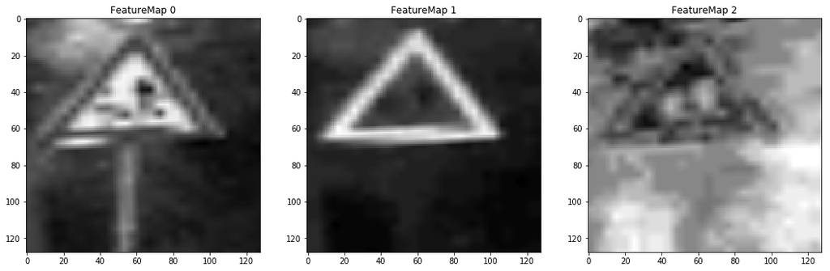

```python
outputFeatureMap(img, x_t)
```

#### ST2 output

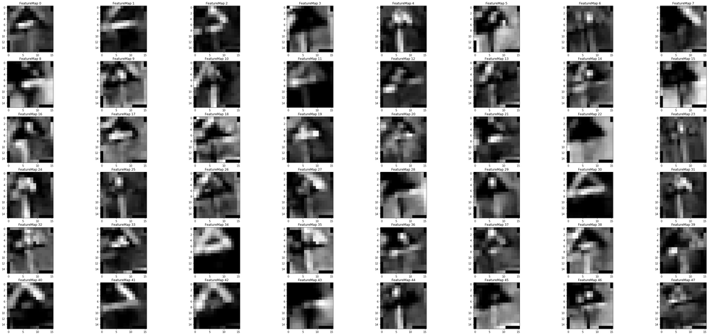

```python
outputFeatureMap(img, conv2_t)
```

#### Inception L3 output

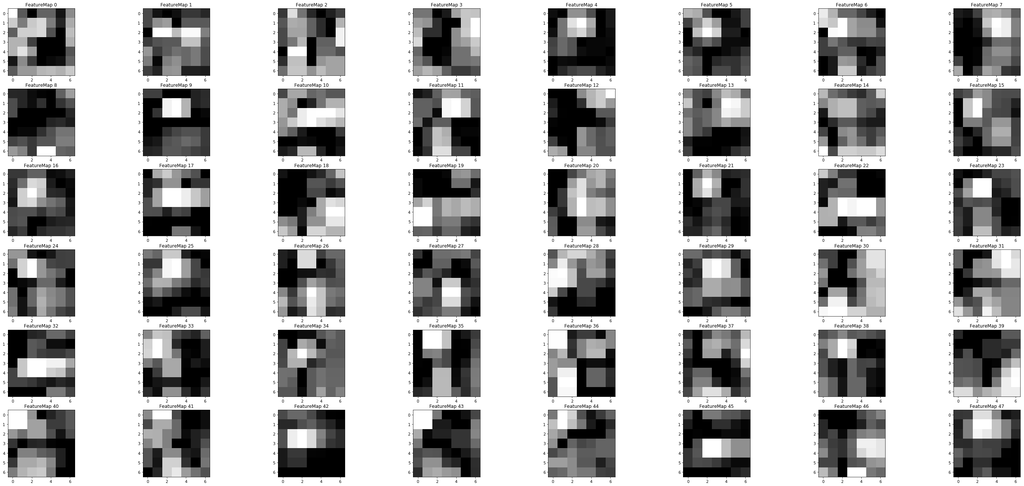

```python
outputFeatureMap(img, inceptionL3)
```

#### Inception L4 output

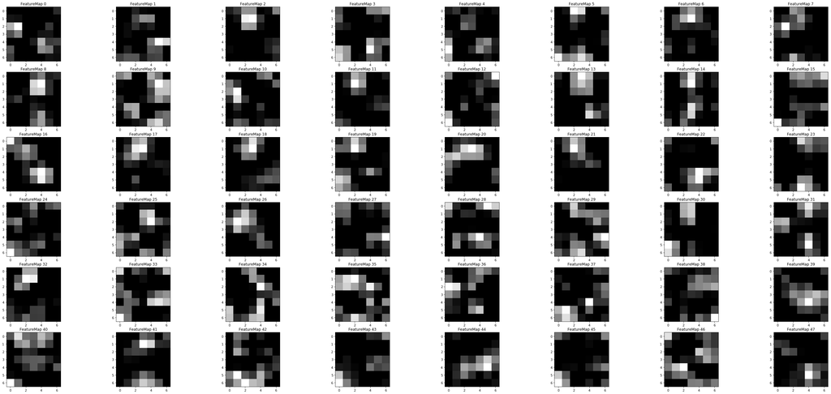

```python
outputFeatureMap(img, inceptionL4)
```

#### Inception L5 output

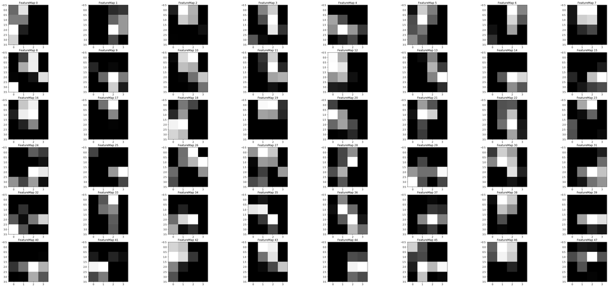

```python
outputFeatureMap(img, inceptionL5)
```